```python
import pandas as pd
import numpy as np
```

# 1.1 ЗАГРУЗКА ДАННЫХ

```python
# загружаем данные и выводим первые 5 строк
df = pd.read_csv('diabetic_data.csv')
df.head()
```

|  | encounter_id | patient_nbr | race | gender | age | weight | admission_type_id | discharge_disposition_id | admission_source_id | time_in_hospital | ... | citoglipton | insulin | glyburide-metformin | glipizide-metformin | glimepiride-pioglitazone | metformin-rosiglitazone | metformin-pioglitazone | change | diabetesMed | readmitted |
| --- | --- | --- | --- | --- | --- | --- | --- | --- | --- | --- | --- | --- | --- | --- | --- | --- | --- | --- | --- | --- | --- |
| 0 | 2278392 | 8222157 | Caucasian | Female | [0-10) | ? | 6 | 25 | 1 | 1 | ... | No | No | No | No | No | No | No | No | No | NO |
| 1 | 149190 | 55629189 | Caucasian | Female | [10-20) | ? | 1 | 1 | 7 | 3 | ... | No | Up | No | No | No | No | No | Ch | Yes | >30 |
| 2 | 64410 | 86047875 | AfricanAmerican | Female | [20-30) | ? | 1 | 1 | 7 | 2 | ... | No | No | No | No | No | No | No | No | Yes | NO |
| 3 | 500364 | 82442376 | Caucasian | Male | [30-40) | ? | 1 | 1 | 7 | 2 | ... | No | Up | No | No | No | No | No | Ch | Yes | NO |
| 4 | 16680 | 42519267 | Caucasian | Male | [40-50) | ? | 1 | 1 | 7 | 1 | ... | No | Steady | No | No | No | No | No | Ch | Yes | NO |

5 rows × 50 columns

# 1.2 ПРЕДВАРИТЕЛЬНОЕ ИЗУЧЕНИЕ

```python
import matplotlib.pyplot as plt
%matplotlib inline
import seaborn as sns
```

Для начала визуализирую распределение целевой переменной

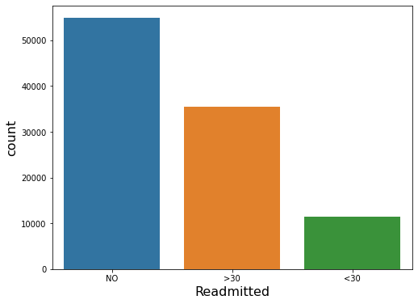

```python
plt.figure(figsize=(8,6))
ax = sns.countplot(data=df, x='readmitted')
ax.set_ylabel('count',size=16)
ax.set_xlabel('Readmitted',size=16);
```

Как можно увидеть, половина пациентов из предоставленных данных не будет повторна принята в какую-либо больницу.

Теперь визуализирую распределение значащих переменных

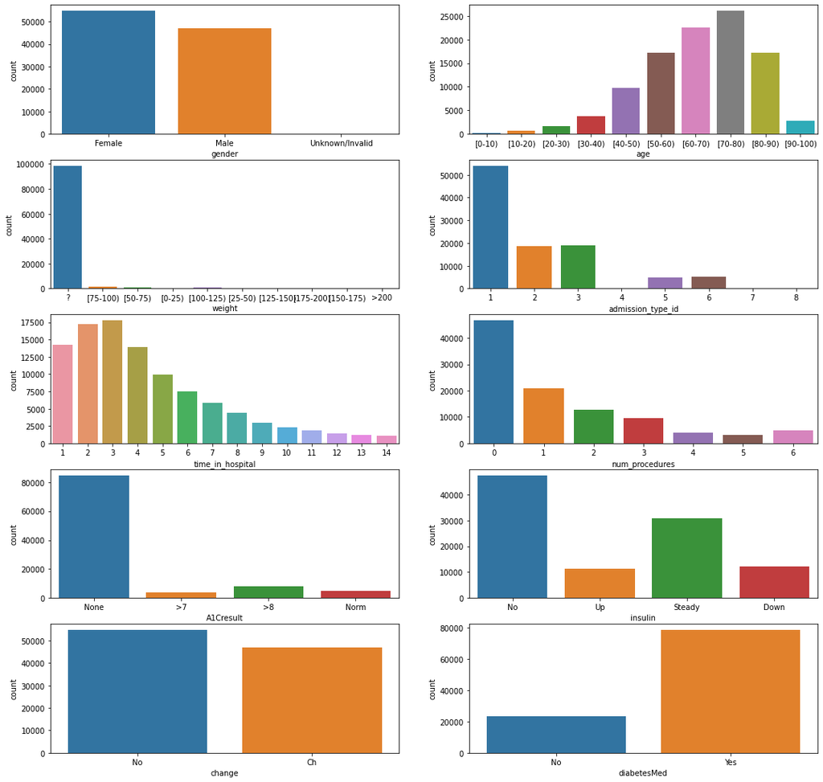

```python
col = ['gender', 'age', 'weight', 'admission_type_id', 'time_in_hospital', 'num_procedures', 'A1Cresult', 'insulin', 'change', 'diabetesMed']
counter=0
fig, ax = plt.subplots(5,2,figsize=(18,18))
for i in range(5):
    for j in range(2):
        sns.countplot(data=df, x=df[col[counter]], ax=ax[i][j])
        counter+=1
```

Как можно увидеть в некоторых столбцах расперделение данных не равномерно, т.к. в них содержиться слишком мало данных.  
Так же можно увидеть, что в столбцах `gender` и `change` данные распределеные равномерно.

# 1.3 ЧИСТКА/ ОБРАБОТКА НЕЗНАЧАЩИХ СИМВОЛОВ В ДАННЫХ

### Обработка незначащих символов

В слобцах `age` и `weight` содержаться не нужные символы, их следует удалить

```python
df['age'] = df['age'].str.replace(r'\(|\)|\[|\]', '', regex=True)
df['weight'] = df['weight'].str.replace(r'\(|\)|\[|\]', '', regex=True)
```

Посмотрим на результат

```python
df.sample(2)
```

|  | encounter_id | patient_nbr | race | gender | age | weight | admission_type_id | discharge_disposition_id | admission_source_id | time_in_hospital | ... | citoglipton | insulin | glyburide-metformin | glipizide-metformin | glimepiride-pioglitazone | metformin-rosiglitazone | metformin-pioglitazone | change | diabetesMed | readmitted |
| --- | --- | --- | --- | --- | --- | --- | --- | --- | --- | --- | --- | --- | --- | --- | --- | --- | --- | --- | --- | --- | --- |
| 54386 | 158359476 | 52701984 | AfricanAmerican | Female | 60-70 | ? | 2 | 1 | 7 | 6 | ... | No | Steady | No | No | No | No | No | No | Yes | >30 |
| 20832 | 73071894 | 13072149 | AfricanAmerican | Male | 50-60 | ? | 1 | 1 | 7 | 1 | ... | No | No | No | No | No | No | No | No | No | NO |

2 rows × 50 columns

### Обработка данных, не соответствующих формату столбца

Для начала нужно вывести столбцы имеющие только бинарные признаки

```python
col = []
df.apply(lambda x: col.append(x.name) if x.nunique()<=2 else x)
df[col].head(2)
```

|  | acetohexamide | tolbutamide | troglitazone | examide | citoglipton | glipizide-metformin | glimepiride-pioglitazone | metformin-rosiglitazone | metformin-pioglitazone | change | diabetesMed |
| --- | --- | --- | --- | --- | --- | --- | --- | --- | --- | --- | --- |
| 0 | No | No | No | No | No | No | No | No | No | No | No |
| 1 | No | No | No | No | No | No | No | No | No | Ch | Yes |

Теперь заменяем занчения на числа и посмотрим на результат

```python
df[col] = df[col].apply(lambda x: x.map(dict(zip(x.unique(), range(x.nunique())))))
df[col].info()
```

```
<class 'pandas.core.frame.DataFrame'>
RangeIndex: 101766 entries, 0 to 101765
Data columns (total 11 columns):
 #   Column                    Non-Null Count   Dtype
---  ------                    --------------   -----
 0   acetohexamide             101766 non-null  int64
 1   tolbutamide               101766 non-null  int64
 2   troglitazone              101766 non-null  int64
 3   examide                   101766 non-null  int64
 4   citoglipton               101766 non-null  int64
 5   glipizide-metformin       101766 non-null  int64
 6   glimepiride-pioglitazone  101766 non-null  int64
 7   metformin-rosiglitazone   101766 non-null  int64
 8   metformin-pioglitazone    101766 non-null  int64
 9   change                    101766 non-null  int64
 10  diabetesMed               101766 non-null  int64
dtypes: int64(11)
memory usage: 8.5 MB
```

# 1.4 ОБРАБОТКА ПУСТЫХ ЗНАЧЕНИЙ

```python
df.replace('?', np.NaN, inplace=True)
```

```python
df.isna().sum()
```

```
encounter_id                    0
patient_nbr                     0
race                         2273
gender                          0
age                             0
weight                      98569
admission_type_id               0
discharge_disposition_id        0
admission_source_id             0
time_in_hospital                0
payer_code                  40256
medical_specialty           49949
num_lab_procedures              0
num_procedures                  0
num_medications                 0
number_outpatient               0
number_emergency                0
number_inpatient                0
diag_1                         21
diag_2                        358
diag_3                       1423
number_diagnoses                0
max_glu_serum                   0
A1Cresult                       0
metformin                       0
repaglinide                     0
nateglinide                     0
chlorpropamide                  0
glimepiride                     0
acetohexamide                   0
glipizide                       0
glyburide                       0
tolbutamide                     0
pioglitazone                    0
rosiglitazone                   0
acarbose                        0
miglitol                        0
troglitazone                    0
tolazamide                      0
examide                         0
citoglipton                     0
insulin                         0
glyburide-metformin             0
glipizide-metformin             0
glimepiride-pioglitazone        0
metformin-rosiglitazone         0
metformin-pioglitazone          0
change                          0
diabetesMed                     0
readmitted                      0
dtype: int64
```

Теперь пустые значения отражаются корректно

```python
# сохранение данных
df.to_csv('preproc_dataset.csv', index=None)
```